# PRED422 Assignment 1

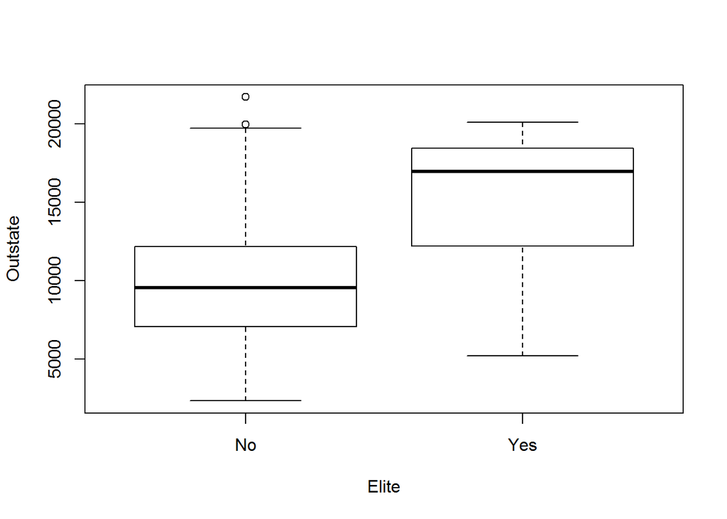

```r
plot(college$Elite,college$Outstate,xlab="Elite",ylab="Outstate")
```

v. Use the hist() function to produce some histograms with differing numbers of bins for a few of the quantitative variables.

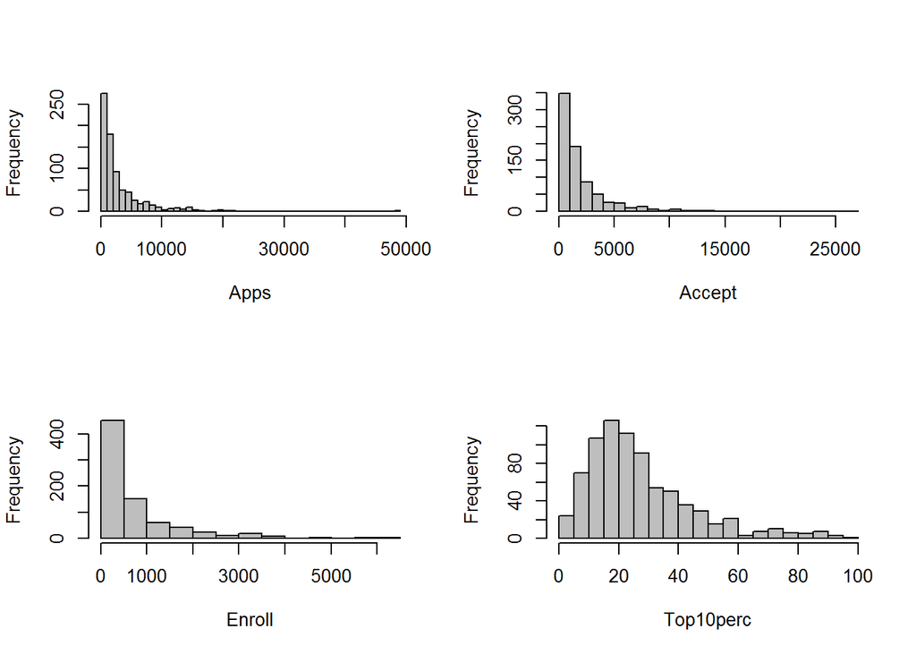

```r
# 8 (c) v.
par(mfrow=c(2,2))
hist(college$Apps,breaks=50,col="gray",xlab="Apps",main="")
hist(college$Accept,breaks=20,col="gray",xlab="Accept",main="")
hist(college$Enroll,breaks=15,col="gray",xlab="Enroll",main="")
hist(college$Top10perc,breaks=15,col="gray",xlab="Top10perc",main="")
```

Exercise 9 (ISLR Section 2.4) This exercise involves the Auto data set studied in the lab

```r
inPath = file.path("C:","playground","Predict422",
                   "R","week1")
# Load data and remove missing values per the lab (Section 2.3.4)
Auto = read.table(file.path(inPath,"Auto.data"),header=TRUE,na.strings="?")
dim(Auto)
Auto = na.omit(Auto)
dim(Auto)
```

1. Which of the predictors are quantitative, and which are qualitative?

```r
# 9 (a)
str(Auto)
summary(Auto)
```

2. What is the range of each quantitative predictor? You can answer this using the range() function.

```r
# 9 (b)
#sapply(Auto[,1:7],range)
for (ii in 1:7)
{
  rng = range(Auto[,ii])
  print(paste(names(Auto)[ii],": ",rng[1]," to ",rng[2],sep=""))
}
```

3. What is the mean and standard deviation of each quantitative predictor?

```r
# 9 (c)
#apply(Auto[,1:7],2,mean)
#apply(Auto[,1:7],2,sd)
sapply(Auto[,1:7],mean)
sapply(Auto[,1:7],sd)
```

4. Now remove the 10th through 85th observations. What is the range, mean, and standard deviation of each predictor in the subset of the data that remains?

```r
# 9 (d) Now remove the 10th through 85th observations.
AutoSubset = Auto[-(10:85),]
sapply(AutoSubset[,1:7],range)
sapply(AutoSubset[,1:7],mean)
sapply(AutoSubset[,1:7],sd)
```

5. Using the full data set, investigate the predictors graphically

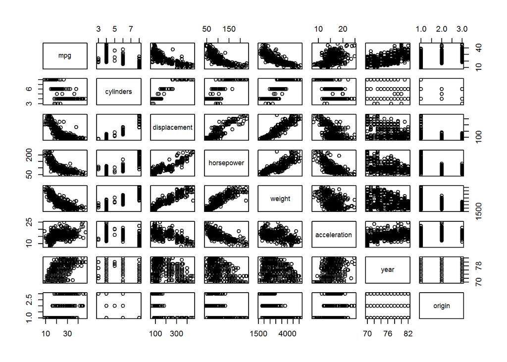

```r
pairs(Auto[,1:8])
```

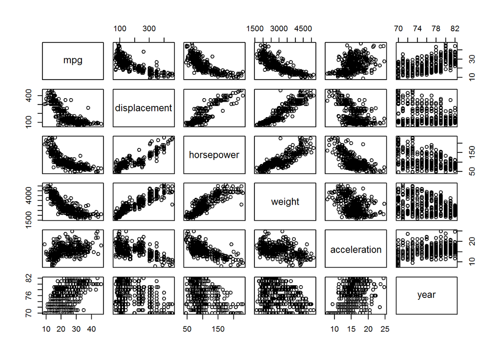

```r
Auto$cylinders = as.factor(Auto$cylinders)
Auto$origin = as.factor(Auto$origin)
pairs(Auto[,c(1,3:7)])
```

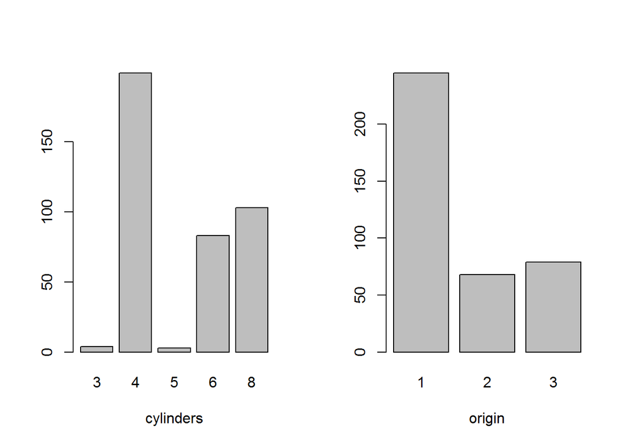

```r
par(mfrow=c(1,2))
barplot(table(Auto$cylinders),xlab="cylinders")
barplot(table(Auto$origin),xlab="origin")
```

6. Suppose that we wish to predict gas mileage (mpg) on the basis of the other variables. Do your plots suggest that any of the other variables might be useful in predicting mpg?

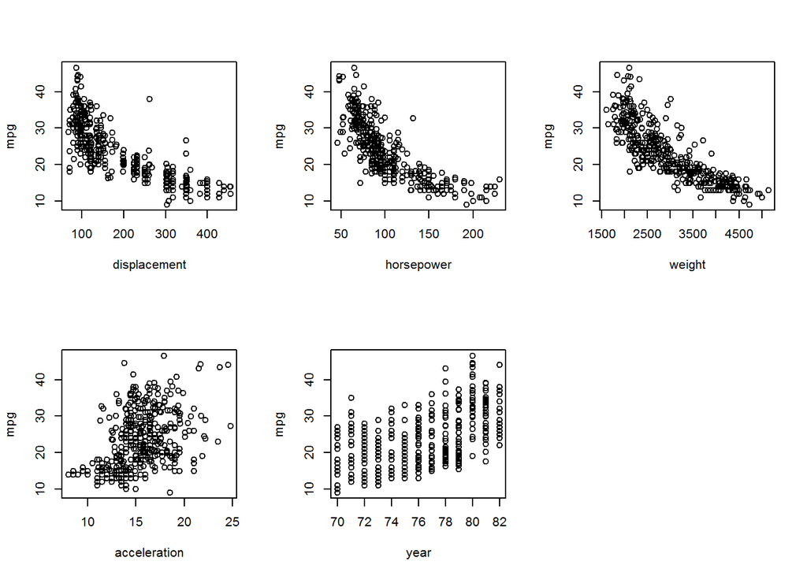

```r
par(mfrow=c(2,3))
plot(Auto$displacement,Auto$mpg,xlab="displacement",ylab="mpg")
# more horsepower correlates with lower mpg
plot(Auto$horsepower,Auto$mpg,xlab="horsepower",ylab="mpg")
#heavier weight correlates with lower mpg
plot(Auto$weight,Auto$mpg,xlab="weight",ylab="mpg")
plot(Auto$acceleration,Auto$mpg,xlab="acceleration",ylab="mpg")
plot(Auto$year,Auto$mpg,xlab="year",ylab="mpg")
#mpg increases over time

par(mfrow=c(1,2))
```

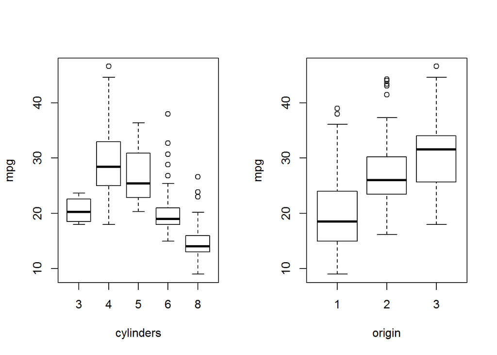

```r
plot(Auto$cylinders,Auto$mpg,xlab="cylinders",ylab="mpg")
plot(Auto$origin,Auto$mpg,xlab="origin",ylab="mpg")
```

More horsepower correlates with lower mpg. Heavier weight correlates with lower mpg. Mpg increases over time as showed above.